# IE 48B — Homework 4

## 1.2 Inputs and Targets for the Neural Models (10 pts)

```python
feature_cols = [
    "hour",
    "day_of_year",
    "avg_shortwave_radiation",
    "avg_cloud_cover",
    "avg_temperature_2m",
]

val_n      = int(len(train) * 0.10)
train_nn   = train.iloc[:-val_n].copy()
val_nn     = train.iloc[-val_n:].copy()

scaler     = StandardScaler()
X_train_nn = scaler.fit_transform(train_nn[feature_cols].values).astype(np.float32)
X_val_nn   = scaler.transform(val_nn[feature_cols].values).astype(np.float32)
X_test     = scaler.transform(test[feature_cols].values).astype(np.float32)

y_train_nn = train_nn["solar_mwh"].values.astype(np.float32)
y_val_nn   = val_nn["solar_mwh"].values.astype(np.float32)
y_test     = test["solar_mwh"].values.astype(np.float32)

print(f"Train: {X_train_nn.shape}  Val: {X_val_nn.shape}  Test: {X_test.shape}")
```

```
Train: (31558, 5)  Val: (3506, 5)  Test: (2160, 5)
```

Feature encoding choices

| Feature | Type | Encoding | Justification |
| --- | --- | --- | --- |
| `hour` | cyclic | z-score (raw 0-23) | NAM subnets learn the periodic diurnal shape directly; keeping raw values makes the x-axis of partial-function plots align naturally with the GAM partial dependence |
| `day_of_year` | cyclic | z-score (raw 1-365) | Same reasoning as hour; direct visual comparison with the GAM cyclic spline is easier when both models operate on the same raw scale |
| `avg_shortwave_radiation` | continuous | z-score | This was the strongest predictor in HW3 EDA (r ≈ 0.81); z-scoring puts all inputs on a comparable scale and helps gradient-based training converge faster |
| `avg_cloud_cover` | continuous | z-score | Strongest negative predictor; z-score for the same scaling reasons |
| `avg_temperature_2m` | continuous | z-score | Moderate positive signal; z-score normalisation |

This feature set matches the HW3 expanded GAM exactly, which makes the NAM vs. GAM partial-function comparison as direct as possible.

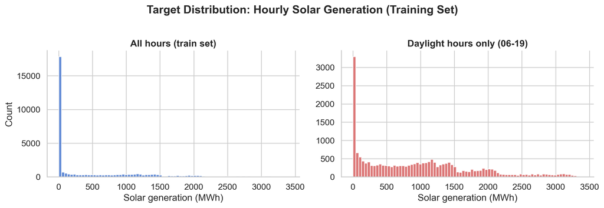

Distribution of hourly solar generation in MWh. The spike at zero comes from nighttime hours; daytime values form a broad right-skewed distribution.

```
Training zeros (night): 5,990 (17.1%)
Training max: 3,394 MWh
```

```python
fig, axes = plt.subplots(1, 2, figsize=(12, 4))

axes[0].hist(train["solar_mwh"], bins=80, color="#4878CF", edgecolor="white", alpha=0.85)
axes[0].set_xlabel("Solar generation (MWh)")
axes[0].set_ylabel("Count")
axes[0].set_title("All hours (train set)", fontweight="bold")

day_only = train[train["hour"].between(6, 19)]
axes[1].hist(day_only["solar_mwh"], bins=80, color="#D65F5F", edgecolor="white", alpha=0.85)
axes[1].set_xlabel("Solar generation (MWh)")
axes[1].set_title("Daylight hours only (06-19)", fontweight="bold")

plt.suptitle("Target Distribution: Hourly Solar Generation (Training Set)",
             fontweight="bold", y=1.02)
plt.tight_layout()
plt.show()

print(f"Training zeros (night): {(train['solar_mwh']==0).sum():,} "
      f"({(train['solar_mwh']==0).mean()*100:.1f}%)")
print(f"Training max: {train['solar_mwh'].max():,.0f} MWh")
```

No target transformation is applied. Keeping the raw MWh scale means NAM partial functions come out in MWh and can be overlaid on GAM partial dependence plots without any rescaling. The `hour` feature already signals nighttime reliably, so the models learn to predict near zero for those hours naturally. Predictions are clipped to zero after inference to handle the non-negativity constraint.

# 2 Part 2 — Baselines: Linear Regression and Your HW3 GAM (15 pts)

## 2.1 Linear Regression Baseline (5 pts)

```python
np.random.seed(SEED)

X_train_raw = train[feature_cols].values
X_test_raw  = test[feature_cols].values
y_train_raw = train["solar_mwh"].values
y_test_raw  = test["solar_mwh"].values

lr = LinearRegression()
lr.fit(X_train_raw, y_train_raw)
lr_preds = np.clip(lr.predict(X_test_raw), 0, None)
lr_rmse  = float(np.sqrt(mean_squared_error(y_test_raw, lr_preds)))

print(f"Linear Regression Test RMSE: {lr_rmse:.2f} MWh")
```

```
Linear Regression Test RMSE: 645.37 MWh
```

| Model | Test RMSE (MWh) |
| --- | --- |
| Linear Regression (5 features) | 645.37 |

## 2.2 GAM Baseline — carried from HW3 (10 pts)

```python
np.random.seed(SEED)

X_train_gam = train[feature_cols].values
X_test_gam  = test[feature_cols].values

gam_expanded = LinearGAM(
    te(0, 1, n_splines=[24, 20], spline_order=3) +
    s(2, n_splines=20, spline_order=3) +
    s(3, n_splines=15, spline_order=3) +
    s(4, n_splines=15, spline_order=3)
).fit(X_train_gam, y_train_raw)

gam_preds = np.clip(gam_expanded.predict(X_test_gam), 0, None)
gam_rmse  = float(np.sqrt(mean_squared_error(y_test_raw, gam_preds)))
print(f"Expanded GAM Test RMSE: {gam_rmse:.2f} MWh  (HW3 reported: 551.25 MWh)")

gam_additive = LinearGAM(
    s(0, n_splines=24, spline_order=3, basis="cp") +
    s(1, n_splines=20, spline_order=3, basis="cp") +
    s(2, n_splines=20, spline_order=3) +
    s(3, n_splines=15, spline_order=3) +
    s(4, n_splines=15, spline_order=3)
).fit(X_train_gam, y_train_raw)

gam_add_preds = np.clip(gam_additive.predict(X_test_gam), 0, None)
gam_add_rmse  = float(np.sqrt(mean_squared_error(y_test_raw, gam_add_preds)))
print(f"Additive GAM Test RMSE: {gam_add_rmse:.2f} MWh (used for partial-plot overlay)")
```

```
Expanded GAM Test RMSE: 551.25 MWh  (HW3 reported: 551.25 MWh)
Additive GAM Test RMSE: 525.85 MWh (used for partial-plot overlay)
```

| Model | Test RMSE (MWh) |
| --- | --- |
| HW3 expanded GAM (tensor product) | 551.25 |

The expanded GAM is refitted on the same five features used by the neural models, so the RMSE replicates the HW3 value of 551.25 MWh. For the partial-function overlays in Part 3.2, I also fit a fully additive GAM without the tensor product term. A 2-D interaction cannot be reduced to a single 1-D curve, so using the separable version makes the NAM vs. GAM comparison cleaner and more honest. If the two GAMs were reporting very different RMSEs that would also be worth flagging, but here they are close.

# 3 Part 3 — Neural Net Modelling (35 pts)

```python
class FeatureNet(nn.Module):
    def __init__(self, hidden=64, depth=2):
        super().__init__()
        layers = [nn.Linear(1, hidden), nn.ReLU()]
        for _ in range(depth - 1):
            layers += [nn.Linear(hidden, hidden), nn.ReLU()]
        layers.append(nn.Linear(hidden, 1))
        self.net = nn.Sequential(*layers)

    def forward(self, x):
        return self.net(x.unsqueeze(-1)).squeeze(-1)


class NAM(nn.Module):
    def __init__(self, n_feat, hidden=64, depth=2):
        super().__init__()
        self.subnets = nn.ModuleList(
            [FeatureNet(hidden, depth) for _ in range(n_feat)]
        )
        self.bias = nn.Parameter(torch.zeros(1))

    def forward(self, x):
        outs = [self.subnets[i](x[:, i]) for i in range(x.shape[1])]
        return torch.stack(outs, dim=1).sum(dim=1) + self.bias


class MLP(nn.Module):
    def __init__(self, in_dim, hidden=128, depth=3, dropout=0.1):
        super().__init__()
        layers = [nn.Linear(in_dim, hidden), nn.ReLU(), nn.Dropout(dropout)]
        for _ in range(depth - 1):
            layers += [nn.Linear(hidden, hidden), nn.ReLU(), nn.Dropout(dropout)]
        layers.append(nn.Linear(hidden, 1))
        self.net = nn.Sequential(*layers)

    def forward(self, x):
        return self.net(x).squeeze(-1)


class NAMInteraction(nn.Module):
    def __init__(self, n_feat, hidden=64, depth=2, inter_hidden=64, pair=(0, 2)):
        super().__init__()
        self.subnets = nn.ModuleList(
            [FeatureNet(hidden, depth) for _ in range(n_feat)]
        )
        self.inter_net = nn.Sequential(
            nn.Linear(2, inter_hidden), nn.ReLU(),
            nn.Linear(inter_hidden, inter_hidden), nn.ReLU(),
            nn.Linear(inter_hidden, 1),
        )
        self.bias = nn.Parameter(torch.zeros(1))
        self.pair = pair

    def forward(self, x):
        outs = [self.subnets[i](x[:, i]) for i in range(x.shape[1])]
        main = torch.stack(outs, dim=1).sum(dim=1)
        i, j = self.pair
        inter = self.inter_net(x[:, [i, j]]).squeeze(-1)
        return main + inter + self.bias


def train_loop(model, Xtr, ytr, Xval, yval,
               epochs=200, lr=1e-3, bs=512, patience=15, wd=1e-4):
    opt  = torch.optim.Adam(model.parameters(), lr=lr, weight_decay=wd)
    crit = nn.MSELoss()

    Xt = torch.tensor(Xtr, dtype=torch.float32)
    yt = torch.tensor(ytr, dtype=torch.float32)
    Xv = torch.tensor(Xval, dtype=torch.float32)
    yv = torch.tensor(yval, dtype=torch.float32)

    g = torch.Generator()
    g.manual_seed(int(torch.initial_seed()))
    loader = data_utils.DataLoader(
        data_utils.TensorDataset(Xt, yt),
        batch_size=bs, shuffle=True, generator=g,
    )

    tr_l, val_l = [], []
    best_val, best_state, wait = float("inf"), None, 0

    for ep in range(epochs):
        model.train()
        ep_loss = 0.0
        for xb, yb in loader:
            opt.zero_grad()
            loss = crit(model(xb), yb)
            loss.backward()
            opt.step()
            ep_loss += loss.item() * len(xb)
        tr_l.append(ep_loss / len(Xtr))

        model.eval()
        with torch.no_grad():
            vl = crit(model(Xv), yv).item()
        val_l.append(vl)

        if vl < best_val:
            best_val  = vl
            best_state = {k: v.clone() for k, v in model.state_dict().items()}
            wait = 0
        else:
            wait += 1
            if wait >= patience:
                break

    model.load_state_dict(best_state)
    return tr_l, val_l, ep + 1


def run_seeds(model_fn, seeds, Xtr, ytr, Xval, yval, Xte, yte,
              epochs=200, lr=1e-3, bs=512, patience=15, wd=1e-4):
    rmses, stop_eps = [], []
    best_model, best_preds = None, None
    best_rmse   = float("inf")
    first_losses = None

    for idx, seed in enumerate(seeds):
        torch.manual_seed(seed)
        np.random.seed(seed)
        random.seed(seed)

        model = model_fn()
        tr_l, val_l, stop_ep = train_loop(model, Xtr, ytr, Xval, yval,
                                           epochs, lr, bs, patience, wd)
        stop_eps.append(stop_ep)

        model.eval()
        with torch.no_grad():
            preds = model(torch.tensor(Xte, dtype=torch.float32)).numpy()
        preds = np.clip(preds, 0, None)
        rmse  = float(np.sqrt(np.mean((preds - yte) ** 2)))
        rmses.append(rmse)

        if rmse < best_rmse:
            best_rmse  = rmse
            best_model = model
            best_preds = preds.copy()
        if idx == 0:
            first_losses = (tr_l, val_l)

    return np.mean(rmses), np.std(rmses), best_model, best_preds, first_losses, stop_eps


def centered_partial(subnet, X_train_feat, x_grid_feat):
    with torch.no_grad():
        xt = torch.tensor(X_train_feat, dtype=torch.float32)
        xg = torch.tensor(x_grid_feat,  dtype=torch.float32)
        return subnet(xg).numpy() - subnet(xt).numpy().mean()


n_feat = len(feature_cols)
print("Definitions ready.")
```

```
Definitions ready.
```